# Analysis of single-cell RNA-seq data: Dimensionality reduction, clustering, and lineage inference

Dennis Dimitri Krutkin

2/1/2022

## Getting Started

1. Dimensionality reduction accounting for zero inflation and over-dispersion and adjusting for gene and cell-level covariates, using the zinbwave Bioconductor package;
2. Robust and stable cell clustering using resampling-based sequential ensemble clustering, as implemented in the clusterExperiment Bioconductor package
3. Inference of cell lineages and ordering of the cells by developmental progression along lineages, using the slingshot R package
4. DE analysis along lineages

Throughout the workflow, we use a single SingleCellExperiment object to store the scRNA-seq data along with any gene or cell-level metadata available from the experiment.

```r
#Clearing the workspace:
rm(list=ls())
```

### The Data

```r
# Bioconductor
library(BiocParallel)
library(SingleCellExperiment)
library(clusterExperiment)
library(scone)
library(zinbwave)
library(slingshot)
# CRAN
library(gam)
library(RColorBrewer)

set.seed(20)
```

### Parallel computing

The BiocParallel package can be used to allow for parallel computing in zinbwave. Here, we use a single CPU to run the function, registering the serial mode of BiocParallel. Users that have access to more than one core in their system are encouraged to use multiple cores to increase speed.

```r
register(SerialParam())
```

## The SingleCellExperiment class

```r
load(file='fletcher.rda')
fletcher
```

```
## class: SingleCellExperiment
## dim: 28284 849
## metadata(0):
## assays(1): counts
## rownames(28284): Xkr4 LOC102640625 ... Ggcx.1 eGFP
## rowData names(0):
## colnames(849): OEP01_N706_S501 OEP01_N701_S501 ... OEL23_N704_S503
##   OEL23_N703_S502
## colData names(19): Experiment Batch ... CreER ERCC_reads
## reducedDimNames(0):
## altExpNames(0):
```

```r
colData(fletcher)
```

```
## DataFrame with 849 rows and 19 columns
##                          Experiment    Batch publishedClusters    NREADS
##                            <factor> <factor>         <numeric> <numeric>
## OEP01_N706_S501     K5ERRY_UI_96HPT      Y01                 1   3313260
## OEP01_N701_S501     K5ERRY_UI_96HPT      Y01                 1   2902430
## OEP01_N707_S507     K5ERRY_UI_96HPT      Y01                 1   2307940
## OEP01_N705_S501     K5ERRY_UI_96HPT      Y01                 1   3337400
## OEP01_N704_S507     K5ERRY_UI_96HPT      Y01                -2    117892
## ...                             ...      ...               ...       ...
## OEL23_N704_S510 K5ERP63CKO_UI_14DPT      P14                -2   2407440
## OEL23_N705_S502 K5ERP63CKO_UI_14DPT      P14                -2   2308940
## OEL23_N706_S502 K5ERP63CKO_UI_14DPT      P14                12   2215640
## OEL23_N704_S503 K5ERP63CKO_UI_14DPT      P14                12   2673790
## OEL23_N703_S502 K5ERP63CKO_UI_14DPT      P14                 7   2450320
##                  NALIGNED    RALIGN TOTAL_DUP    PRIMER PCT_RIBOSOMAL_BASES
##                 <numeric> <numeric> <numeric> <numeric>           <numeric>
## OEP01_N706_S501   3167600   95.6035   47.9943 0.0154566             2.0e-06
## OEP01_N701_S501   2757790   95.0167   45.0150 0.0182066             0.0e+00
## OEP01_N707_S507   2178350   94.3852   43.7832 0.0219196             0.0e+00
## OEP01_N705_S501   3183720   95.3952   43.2688 0.0183041             2.0e-06
## OEP01_N704_S507     98628   83.6596   18.0576 0.0623744             1.4e-05
## ...                   ...       ...       ...       ...                 ...
## OEL23_N704_S510   2305060   95.7472   47.1489 0.0159111               0e+00
## OEL23_N705_S502   2203300   95.4244   62.5638 0.0195812               0e+00
## OEL23_N706_S502   2108490   95.1637   50.6643 0.0182207               7e-06
## OEL23_N704_S503   2568300   96.0546   60.5481 0.0155611               0e+00
## OEL23_N703_S502   2363500   96.4567   48.4164 0.0122704               8e-06
##                 PCT_CODING_BASES PCT_UTR_BASES PCT_INTRONIC_BASES
##                        <numeric>     <numeric>          <numeric>
## OEP01_N706_S501         0.200130      0.230654           0.404205
## OEP01_N701_S501         0.182461      0.201810           0.465702
## OEP01_N707_S507         0.152627      0.207897           0.511416
## OEP01_N705_S501         0.169514      0.207342           0.457556
## OEP01_N704_S507         0.110724      0.199174           0.489514
## ...                          ...           ...                ...
## OEL23_N704_S510         0.287346      0.314104           0.250658
## OEL23_N705_S502         0.337264      0.297077           0.230214
## OEL23_N706_S502         0.244333      0.262663           0.355899
## OEL23_N704_S503         0.343203      0.338217           0.174696
## OEL23_N703_S502         0.259367      0.238239           0.376091
```

[output cut: 11 more lines]

```
## OEL23_N704_S503             0.143885       0.681420           0.745201
## OEL23_N703_S502             0.126294       0.497606           0.711685
##                 MEDIAN_5PRIME_BIAS MEDIAN_3PRIME_BIAS     CreER ERCC_reads
##                          <numeric>          <numeric> <numeric>  <numeric>
## OEP01_N706_S501           0.061028           0.521079         1      10516
## OEP01_N701_S501           0.033350           0.373993      3022       9331
## OEP01_N707_S507           0.014606           0.491230      2329       7386
## OEP01_N705_S501           0.101798           0.525238       717       6387
## OEP01_N704_S507           0.000000           0.706512        60        992
## ...                            ...                ...       ...        ...
## OEL23_N704_S510           0.198224           0.419745       659          0
## OEL23_N705_S502           0.105091           0.398755      1552          0
## OEL23_N706_S502           0.103363           0.431862         0          0
## OEL23_N704_S503           0.118615           0.384220         0          0
## OEL23_N703_S502           0.196725           0.377926      2222          0
```

## Pre-processing

### Sample filtering

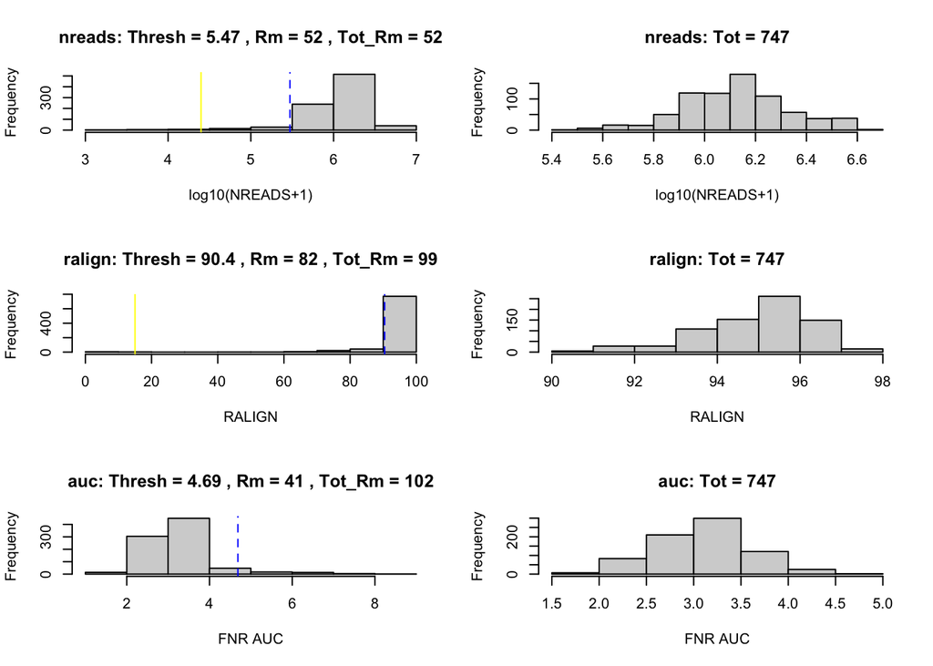

```r
# QC-metric-based sample-filtering
data("housekeeping")

hk = rownames(fletcher)[toupper(rownames(fletcher)) %in% housekeeping$V1]

mfilt = metric_sample_filter(counts(fletcher),
                             nreads = colData(fletcher)$NREADS,
                             ralign = colData(fletcher)$RALIGN,
                             pos_controls = rownames(fletcher) %in% hk,
                             zcut = 3, mixture = FALSE,
                             plot = TRUE)
```

## Normalization and dimensionality reduction: ZINB-WaVE